# Homework 3

Jonathan Hernandez

February 21, 2018

3.2

Using the normalPlot library/function for a through d

```r
library(openintro)
x <- rnorm(10000)
# zscore_ are the variables for answers a through d
zscore_a <- pnorm(-1.13)
zscore_b <- pnorm(0.18, lower.tail = FALSE)
zscore_c <- pnorm(8, lower.tail = FALSE)
zscore_d <- pnorm(0.5) - pnorm(-0.5)
zscore_c
```

```
## [1] 6.220961e-16
```

```r
zscore_b
```

```
## [1] 0.4285763
```

```r
zscore_a
```

```
## [1] 0.1292381
```

```r
zscore_d
```

```
## [1] 0.3829249
```

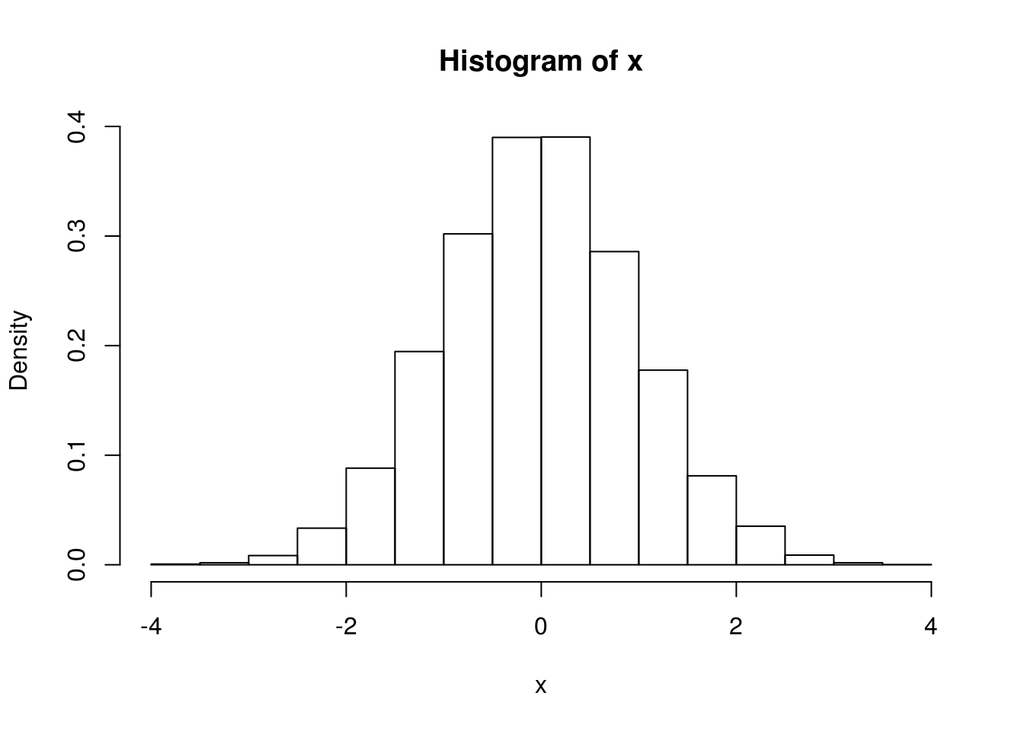

```r
hist(x, probability = TRUE)
```

3.4 a) short hand notation for these two normal distributions:

Men, Ages 30-34 ~ N(4313,583) Woman, Ages 25-29 ~ N(5261,807)

2. Z-score for Leo:

```r
z_leo <- (4948-4313) / 583
z_mary <- (5513-5261) / 807

z_leo
```

```
## [1] 1.089194
```

```r
z_mary
```

```
## [1] 0.3122677
```

These shows that the z scores are > 0 and for Leo he performed well above the average and Mary performed slighty above the average.

3. Yes they ranked above their respective ranks. As not only their time was above the average,

their Z score was positive.

4. and e) using pnorm R function:

```r
prob_leo <- pnorm(4948, mean = 4313, sd = 583)
prob_mary <- pnorm(5513, mean = 5261, sd = 807)
prob_leo
```

```
## [1] 0.8619658
```

```r
prob_mary
```

```
## [1] 0.6225814
```

Looking at the probabilities, Leo performed at around 86% above the rest in his group. and Mary performed at

around 62% above the rest in her group.

6. Yes as the Z score is for nearly normal distributions and cannot be calculated or would make sense.

the data would also change and the percents would change as well based on the distribution and data.

3.18

1. using the data:

```r
female_heights <- c(54, 55, 56, 56, 57, 58, 58, 59, 60, 60, 60, 61,
                    61, 62, 62, 63, 63, 63, 64, 65, 65, 67, 67, 69, 73)

one_sd <- c(61.52-4.58, 61.52+4.58) # 68%
two_sd <- c(61.52-9.16, 61.52+9.16) # 95%
three_sd <- c(61.52-13.74, 61.52+13.74) # 99%
one_sd
```

```
## [1] 56.94 66.10
```

```r
two_sd
```

```
## [1] 52.36 70.68
```

```r
three_sd
```

```
## [1] 47.78 75.26
```

```r
sum(female_heights > one_sd[1] & female_heights < one_sd[2]) # how many are within one sd
```

```
## [1] 17
```

```r
sum(female_heights > two_sd[1] & female_heights < two_sd[2]) # how many are within two sd
```

```
## [1] 24
```

```r
sum(female_heights > three_sd[1] & female_heights < three_sd[2]) # how many are within three sd
```

```
## [1] 25
```

Using the sum function to count how many values fall within their range, we can see that

17/25 = .68 shows that the 68% rule works

24/25 = 0.96 which is 1% more than the standard 95% rule

25/25 = 1 which is 1% more than the standard 99% rule, therefore, the heights do approximately

adhere to the 68 95 99% rule.

2. using the qqnormsim function:

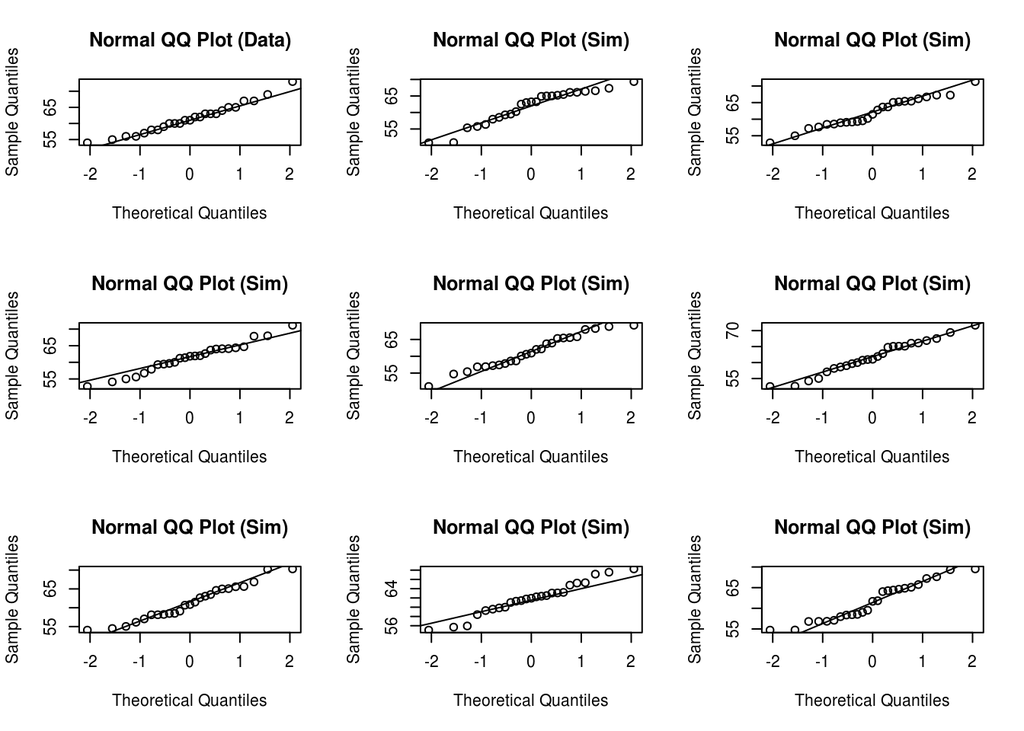

```r
setwd("~/Desktop/CUNYSPS/IS606/DATA606/Labs/Lab3")
load("more/bdims.RData")
qqnormsim(female_heights)
```

using qqnormsim, the data appear to be approximately normal and that the simulated Q-Q plots

show most points on the line and a few away from it.

3.22

1. give that P(defective) = 0.02, then P(effective) = 1 - P(defective) = 1 - 0.02 = 0.98

lets make the “success” to be a defective and the failure to be a effective

then the probability that the 10th transisitor made is the first with a defect is

P(effective)^10-1*P(defective)

using R

```r
(0.98 ^ 9)*0.02
```

```
## [1] 0.01667496
```

which is about %1.6 chance of getting a first defective on a transititor on the 10th one

2. if in a batch of 100 tranisitors all are effective, then

```r
0.98^99
```

```
## [1] 0.1353261
```

which gives about 13% chance of all 100 being effective

3. using the formulas in a geometric distribution the ean is 1/P(defective) and the standard

deviation is sqrt(1-P(defective)/P(defective)^2)

```r
mean_transitors <- 1/0.02
sd_transititors <- sqrt(0.98 / (0.02^2) )
mean_transitors
```

```
## [1] 50
```

```r
sd_transititors
```

```
## [1] 49.49747
```

4. changing the defective rate to 5% (0.05)

```r
mean_transitors2 <- 1/0.05
sd_transititors2 <- sqrt(0.95 / (0.05^2) )
mean_transitors2
```

```
## [1] 20
```

```r
sd_transititors2
```

```
## [1] 19.49359
```

3.38

P(Boy) = 0.51 P(Girl) = 0.49 3 kids

1. binomial model

n choose k* p<sup>k(1-p)</sup>n-k

n = 3, p = 0.51, k = 2

using R

```r
boy <- choose(3, 2) * (0.51^2) * (0.49^1)
boy
```

```
## [1] 0.382347
```

There is about 38% of two children will be boys out of 3 kids.

2. let B be boy and G be girl

{BBB, BBG, BGB, BGG, GBB, GBG, GGB, GGG}

3/8 are exactly 2 boys = 0.375 or about 37.5% probability which is about the same as in a

3. writing down the sample space or is 2^8 or 256 possibilities to write, as such it is better

to use the binomial distribution.

3.42

P(serve) = 0.15 P(not serve) = 0.85

1. n = 10, k = 3 so

P(3rd successful on 10th try) using R

```r
serve <- choose(10,3) * (0.15^3) * (0.85^7)
serve
```

```
## [1] 0.1298337
```

Probability is about 13% of getting a 3rd successful server after 10 tries.

2. adding the two bibomial distributions

first one: n = 9, k = 2

second one: k = 1

adding them gives:

```r
serve2 <- choose(9,2) * (0.15^2) * (0.85^7)
serve3 <- 0.15

serve2 + serve3
```

```
## [1] 0.4096674
```

There is about 40% chance she gets 2 serves in nine attemps and the 10 one is a serve.

3. The number of trials were calculated and number of successes were different and adding the two

is what makes the answers different.